#### Define functions:

```r
rm(list=ls(all=TRUE))


# define functions
f.usePackage = function(p) {
    if (!is.element(p, installed.packages()[,1])) {
        install.packages(p, dep = TRUE);
    }
    require(p, character.only = TRUE);
}

f.getTitle = function(data) {
    title.start = regexpr("\\,[A-Z ]{1,20}\\.", data, TRUE)
    title.end = title.start + attr(title.start, "match.length") - 1
    Title = substr(data, title.start+2, title.end-1)
    return (Title)
}

`%ni%` = Negate(`%in%`)

f.cutoff.optimizer = function(pred, y) {
    output.auc = vector()
    grid = seq(0.1, 0.99, by=0.01)
    for (cut.i in 1:length(grid)) {
        yhat = ifelse(pred >= grid[cut.i], 1, 0)
        result = prediction(yhat, y)
        perf = performance(result,"tpr","fpr")
        auc = performance(result,"auc")
        auc = unlist(slot(auc, "y.values"))
        output.auc = rbind(output.auc, auc)
    }
    output = cbind(grid, output.auc)
    return(output)
}

f.logloss = function(actual, pred) {
    eps = 1e-15
    nr = nrow(pred)
    pred = matrix(sapply(pred, function(x) max(eps,x)), nrow = nr)
    pred = matrix(sapply(pred, function(x) min(1-eps,x)), nrow = nr)
    ll = sum(actual*log(pred) + (1-actual)*log(1-pred))
    ll = -ll/nr
    return(ll);
}

f.cutoff.optimizer = function(pred, y) {
    output.auc <- vector()
    grid = seq(0.1, 0.99, by=0.01)
    for (cut.i in 1:length(grid)) {
        yhat = ifelse(pred >= grid[cut.i], 1, 0)
        result = prediction(yhat, y)
        perf = performance(result,"tpr","fpr")
        auc = performance(result,"auc")
        auc = unlist(slot(auc, "y.values"))
        output.auc = rbind(output.auc, auc)
    }
    output = cbind(grid=grid, auc=output.auc)
    return(output)
}

f.lasso.modeller = function(x.train, y.train, x.test, y.test){
    # Use cv.glmnet() to determine the best lambda for the lasso:
    lasso.cv = cv.glmnet(x=x.train, y=y.train, alpha=1, family='binomial', type.measure='auc', nfolds=10)
    bestlam.lasso = lasso.cv$lambda.min

    # Calculate the predicted outcome of the training and test sets:
    fitted = predict(lasso.cv, s=bestlam.lasso, newx=x.train, type='response')
    pred = predict(lasso.cv, s=bestlam.lasso, newx=x.test, type='response')

    y.train = as.numeric(as.character(y.train))
    y.test = as.numeric(as.character(y.test))

    # Calculate the log-loss of the test
    logloss = f.logloss(actual=y.test, pred=pred)

    # Find the optimal probability cutoff with highest accuracy
    output = f.cutoff.optimizer(fitted, y.train)
    output = data.frame(output)
    OptimalCutoff = output[which.max(output[,2]),c("grid")]

    # Use the optimal probability cutoff to calcuate the accuracy of test data
    pred.binary = ifelse(pred>=OptimalCutoff, 1, 0)
    conf.table = confusionMatrix(table(pred=pred.binary, actual=y.test))
    pred.accuracy = as.numeric(conf.table$overall[1])
    #sens = as.numeric(conf.table$byClass[2])
    #spec = as.numeric(conf.table$byClass[1])
    #kappa = as.numeric(conf.table$overall[2])

    rm(pred, fitted, lasso.cv, bestlam.lasso, pred.binary, output)

    return(c(logloss, OptimalCutoff, pred.accuracy))
}
```

#### Load libraries:

```r
f.usePackage("data.table")
f.usePackage("glmnet")
f.usePackage("dplyr")
f.usePackage("pROC")
f.usePackage("ROCR")
f.usePackage("caret")
```

#### Change working directory:

```r
setwd("C:/Users/chang_000/Dropbox/Pinsker/CV_Resume/InterviewQuestions/Avant/avant-analytics-interview/")
```

#### Read data sets:

```r
data1 = fread("TitanicData.csv")
data2 = fread("TitanicData2.csv")
data1 = data.frame(data1)
data2 = data.frame(data2)

str(data1)
```

```
## 'data.frame':    459 obs. of  8 variables:
##  $ PassengerId: int  1 2 3 4 5 6 7 8 9 10 ...
##  $ Survived   : int  0 1 1 1 0 0 0 0 1 1 ...
##  $ Pclass     : int  3 1 3 1 3 3 1 3 3 2 ...
##  $ Name       : chr  "Braund, Mr. Owen Harris" "Cumings, Mrs. John Bradley (Florence Briggs Thayer)" "Heikkinen, Miss. Laina" "Futrelle, Mrs. Jacques Heath (Lily May Peel)" ...
##  $ Sex        : chr  "male" "female" "female" "female" ...
##  $ Age        : num  22 38 26 35 35 NA 54 2 27 14 ...
##  $ Fare       : num  7.25 71.28 7.92 53.1 8.05 ...
##  $ Embarked   : chr  "S" "C" "S" "S" ...
```

```r
str(data2)
```

```
## 'data.frame':    432 obs. of  8 variables:
##  $ Survived   : int  0 1 0 0 0 0 0 0 0 0 ...
##  $ PassengerId: int  460 461 462 463 464 465 466 467 468 469 ...
##  $ Name       : chr  "O'Connor, Mr. Maurice" "Anderson, Mr. Harry" "Morley, Mr. William" "Gee, Mr. Arthur H" ...
##  $ Sex        : int  0 0 0 0 0 0 0 0 0 0 ...
##  $ Age        : num  NA 48 34 47 48 NA 38 NA 56 NA ...
##  $ Pclass     : int  3 1 3 1 2 3 3 2 1 3 ...
##  $ Fare       : chr  "7.75" "2,655.00" "8.05" "38.5" ...
##  $ Embarked   : chr  "Q" "S" "S" "S" ...
```

```r
unique(data1$PassengerId)
```

[output not shown]

```r
unique(data2$PassengerId)
```

[output not shown]

## Data Manipulation

#### Data1

```r
data1$Survived = as.factor(data1$Survived)
data1$Sex = as.factor(ifelse(data1$Sex=="male", 0, 1))
data1$Pclass = as.factor(data1$Pclass)
```

#### Data2

```r
# data2
data2$Survived = as.factor(data2$Survived)
data2$Sex = as.factor(data2$Sex)
data2$Pclass = as.factor(data2$Pclass)
data2$Fare = as.numeric(gsub(",","",data2$Fare))
```

#### Merge the two data sets:

```r
variables_list = names(data1)[order(names(data1))]
data = rbind(data1[,variables_list], data2[,variables_list])
dim(data)
```

```
## [1] 891   8
```

```r
summary(data)
```

```
##       Age          Embarked              Fare               Name
##  Min.   : 0.42   Length:891         Min.   :     0.00   Length:891
##  1st Qu.:20.12   Class :character   1st Qu.:     7.91   Class :character
##  Median :28.00   Mode  :character   Median :    14.45   Mode  :character
##  Mean   :29.70                      Mean   :   320.95
##  3rd Qu.:38.00                      3rd Qu.:    31.27
##  Max.   :80.00                      Max.   :254667.00
##  NA's   :177
##   PassengerId    Pclass  Sex     Survived
##  Min.   :  1.0   1:216   0:577   0:549
##  1st Qu.:223.5   2:184   1:314   1:342
##  Median :446.0   3:491
##  Mean   :446.0
##  3rd Qu.:668.5
##  Max.   :891.0
##
```

#### Remove the duplicates if there are any in the merged data set:

```r
data = data[!duplicated(data), ]
dim(data)
```

```
## [1] 891   8
```

#### Extract some additional information from the `Name` variable:

```r
# data$Title
data$Title = f.getTitle(data$Name)
table(data$Title)
```

```
##
##         Capt          Col          Don           Dr     Jonkheer
##            1            2            1            7            1
##         Lady        Major       Master         Miss         Mlle
##            1            2           40          182            2
##          Mme           Mr          Mrs           Ms          Rev
##            1          517          125            1            6
##          Sir the Countess
##            1            1
```

```r
# reduce the levels of the "Title" variable
data$Title[data$Title %in% c("Mme","Mlle","Lady","Ms","the Countess", "Jonkheer")] = "OtherFemale"
data$Title[data$Title %in% c("Capt", "Don", "Major", "Sir","Col","Dr","Rev")] = "OtherMale"
data$Title = as.factor(data$Title)
```

#### Detect and impute the missing values:

```r
apply(is.na(data), 2, sum)
```

```
##         Age    Embarked        Fare        Name PassengerId      Pclass
##         177           0           0           0           0           0
##         Sex    Survived       Title
##           0           0           0
```

#### Impute the missing values of “Age” variable:

```r
# impute the missing values of "Age" variable
for (i in 1:nrow(data)) {
    if (is.na(data$Age[i])) {
        data$Age[i] = median(data$Age[data$Title==data$Title[i] & data$Pclass==data$Pclass[i]], na.rm=TRUE)
    }
}
```

#### Bin Age:

```r
obj = cut(data$Age, c(seq(0, 60, 10),Inf), labels=c(0:6))
data$Age_bin = as.factor(obj)
```

#### Fare:

#### There are two outliers (ID 461 ($2655) and ID 486 ($254667)) in the “Fare” variable. Replace the fares of the outliers with the median of the respective groups:

```r
data[data$Fare > 1000,]
```

```
##     Age Embarked   Fare                   Name PassengerId Pclass Sex
## 461  48        S   2655    Anderson, Mr. Harry         461      1   0
## 486  18        S 254667 Lefebre, Miss. Jeannie         486      3   1
##     Survived Title Age_bin
## 461        1    Mr       4
## 486        0  Miss       1
```

```r
# Adjust 2 outliers
for (i in 1:nrow(data)) {
    if (data$Fare[i] > 1000) {
        data$Fare[i] = median(data$Fare[data$Title==data$Title[i] & data$Pclass==data$Pclass[i] & data$Embarked==data$Embarked[i]], na.rm=TRUE)
    }
}
```

#### Log-transformation of Fare, log(Fare), to make the distribution more close to Gaussian:

```r
data$logFare = ifelse(data$Fare > 0, log(data$Fare), log(0.001))
```

#### Impute the missing values of Embarked:

```r
table(data$Embarked) # S is the majority
```

```
##
##       C   Q   S
##   2 168  77 644
```

```r
data$Embarked[data$Embarked == ""] = "S" # impute missing value of Embarked
data$Embarked = as.factor(data$Embarked)
```

#### Save the new data set:

```r
write.csv(data,"mergeddata.csv", row.names=FALSE)
```

## Produce a glmnet model predicting the chance that a Titanic passanger survived:

#### Four models are considered:

#### Model 1: Survived ~ Age + Fare + Embarked + Pclass + Sex + Title

#### Model 2: Survived ~ Age_bin + Fare + Embarked + Pclass + Sex + Title

#### Model 3: Survived ~ Age + logFare + Embarked + Pclass + Sex + Title

#### Model 4: Survived ~ Age_bin + logFare + Embarked + Pclass + Sex + Title

#### K-fold CV (K=10) was adopted to calcuate the means of log-loss and accuracy of the test set of inidividual models, as well as the optimal probability cutoff of the classifiers:

```r
set.seed(1234)

# set up of K-fold CV for validation
K = 10
block = sample(1:K, nrow(data), replace=TRUE)

# Lasso models:
yvariable = c("Survived")
mod1.xvariables = c("Age","Fare","Embarked","Pclass","Sex","Title")
mod2.xvariables = c("Age_bin","Fare","Embarked","Pclass","Sex","Title")
mod3.xvariables = c("Age","logFare","Embarked","Pclass","Sex","Title")
mod4.xvariables = c("Age_bin","logFare","Embarked","Pclass","Sex","Title")

# initiate tables for the outputs
cv.logloss <- cv.OptimalCutoff <- cv.accuracy <- matrix(0, K, 4)


for (i in 1:K) {
    train.data = data[block!=i,]
    test.data = data[block==i,]

    #=========================================================
    # Model 1: Age + Embarked + Fare + Pclass + Sex + Title

    train = train.data[,c(yvariable,mod1.xvariables)]
    test = test.data[,c(yvariable,mod1.xvariables)]

    x.train = model.matrix(Survived~., train)[,-1]
    y.train = train$Survived

    x.test = model.matrix(Survived~., test)[,-1]
    y.test = test$Survived

    temp = f.lasso.modeller(x.train, y.train, x.test, y.test)

    cv.logloss[i,1] = temp[1]
    cv.OptimalCutoff[i,1] = temp[2]
    cv.accuracy[i,1] = temp[3]

    rm(train, test, x.train, y.train, x.test, y.test, temp)

    #=========================================================
    # Model 2:
    train = train.data[,c(yvariable,mod2.xvariables)]
    test = test.data[,c(yvariable,mod2.xvariables)]

    x.train = model.matrix(Survived~., train)[,-1]
    y.train = train$Survived

    x.test = model.matrix(Survived~., test)[,-1]
    y.test = test$Survived

    temp = f.lasso.modeller(x.train, y.train, x.test, y.test)

    cv.logloss[i,2] = temp[1]
    cv.OptimalCutoff[i,2] = temp[2]
    cv.accuracy[i,2] = temp[3]

    rm(train, test, x.train, y.train, x.test, y.test, temp)

    #=========================================================
    # Model 3:
    train = train.data[,c(yvariable,mod3.xvariables)]
    test = test.data[,c(yvariable,mod3.xvariables)]

    x.train = model.matrix(Survived~., train)[,-1]
    y.train = train$Survived

    x.test = model.matrix(Survived~., test)[,-1]
    y.test = test$Survived

    temp = f.lasso.modeller(x.train, y.train, x.test, y.test)

    cv.logloss[i,3] = temp[1]
    cv.OptimalCutoff[i,3] = temp[2]
    cv.accuracy[i,3] = temp[3]

    rm(train, test, x.train, y.train, x.test, y.test, temp)

    #=========================================================
    # Model 4:
    train = train.data[,c(yvariable,mod4.xvariables)]
    test = test.data[,c(yvariable,mod4.xvariables)]

    x.train = model.matrix(Survived~., train)[,-1]
    y.train = train$Survived

    x.test = model.matrix(Survived~., test)[,-1]
    y.test = test$Survived

    temp = f.lasso.modeller(x.train, y.train, x.test, y.test)

    cv.logloss[i,4] = temp[1]
    cv.OptimalCutoff[i,4] = temp[2]
    cv.accuracy[i,4] = temp[3]

    rm(train, test, x.train, y.train, x.test, y.test, temp)

}
```

#### Calculate the means of test log-loss of the models:

```r
cv.logloss = data.frame(cv.logloss)
colnames(cv.logloss) = c("Model 1", "Model 2", "Model 3", "Model 4")
rownames(cv.logloss) = 1:K
cv.logloss
```

```
##      Model 1   Model 2   Model 3   Model 4
## 1  0.4786715 0.4740996 0.4603159 0.4772323
## 2  0.4076372 0.4185719 0.4069859 0.4068599
## 3  0.4435704 0.4505850 0.4406315 0.4388841
## 4  0.4180025 0.4382364 0.4115908 0.4289785
## 5  0.4820811 0.4875695 0.4791176 0.4996979
## 6  0.4420015 0.4467586 0.4401667 0.4478661
## 7  0.5078707 0.5093092 0.5107266 0.4951952
## 8  0.4508919 0.4571971 0.4624762 0.4705474
## 9  0.4552923 0.4544791 0.4563447 0.4564238
## 10 0.3968965 0.4049638 0.3936101 0.4044675
```

```r
apply(cv.logloss, 2, mean)
```

```
##   Model 1   Model 2   Model 3   Model 4
## 0.4482915 0.4541770 0.4461966 0.4526153
```

Model 3 has the smallest log-loss.

#### Calculate the means of test accuracy of the models:

```r
cv.accuracy = data.frame(cv.accuracy)
colnames(cv.accuracy) = c("Model 1", "Model 2", "Model 3", "Model 4")
rownames(cv.accuracy) = 1:K
cv.accuracy
```

```
##      Model 1   Model 2   Model 3   Model 4
## 1  0.7594937 0.6962025 0.8354430 0.7215190
## 2  0.7954545 0.7840909 0.8068182 0.7954545
## 3  0.7386364 0.7727273 0.7386364 0.7500000
## 4  0.8526316 0.8421053 0.8631579 0.8421053
## 5  0.7179487 0.6923077 0.7179487 0.6923077
## 6  0.8333333 0.8333333 0.8333333 0.7843137
## 7  0.7282609 0.7826087 0.7391304 0.7500000
## 8  0.8170732 0.8170732 0.7926829 0.7682927
## 9  0.7560976 0.7804878 0.7439024 0.7439024
## 10 0.8285714 0.8476190 0.8285714 0.8380952
```

```r
apply(cv.accuracy, 2, mean)
```

```
##   Model 1   Model 2   Model 3   Model 4
## 0.7827501 0.7848556 0.7899625 0.7685991
```

Model 3 has the highest test accuracy for the survivability prediction.

#### Print the optimal cutoffs for the models in the k-th folds:

```r
cv.OptimalCutoff = data.frame(cv.OptimalCutoff)
colnames(cv.OptimalCutoff) = c("Model 1", "Model 2", "Model 3", "Model 4")
rownames(cv.OptimalCutoff) = 1:K
cv.OptimalCutoff
```

```
##    Model 1 Model 2 Model 3 Model 4
## 1     0.46    0.32    0.57    0.38
## 2     0.55    0.55    0.55    0.58
## 3     0.33    0.43    0.34    0.36
## 4     0.49    0.47    0.38    0.48
## 5     0.44    0.38    0.47    0.40
## 6     0.57    0.56    0.57    0.40
## 7     0.47    0.50    0.54    0.58
## 8     0.56    0.52    0.42    0.39
## 9     0.56    0.51    0.52    0.62
## 10    0.54    0.53    0.55    0.61
```

```r
#apply(cv.OptimalCutoff, 2, mean)
```

#### Because Model 3 has the smallest test log-loss and the highest test accuracy, build Model 3 using the Full data:

```r
dataset = data[,c(yvariable,mod3.xvariables)]

x = model.matrix(Survived~., dataset)[,-1]
y = dataset$Survived

# Use cv.glmnet() to determine the best lambda for the lasso:
mod.lasso = cv.glmnet(x=x, y=y, alpha=1, family='binomial', type.measure='auc', nfolds=10)
(bestlam.lasso = mod.lasso$lambda.min)
```

```
## [1] 0.01239704
```

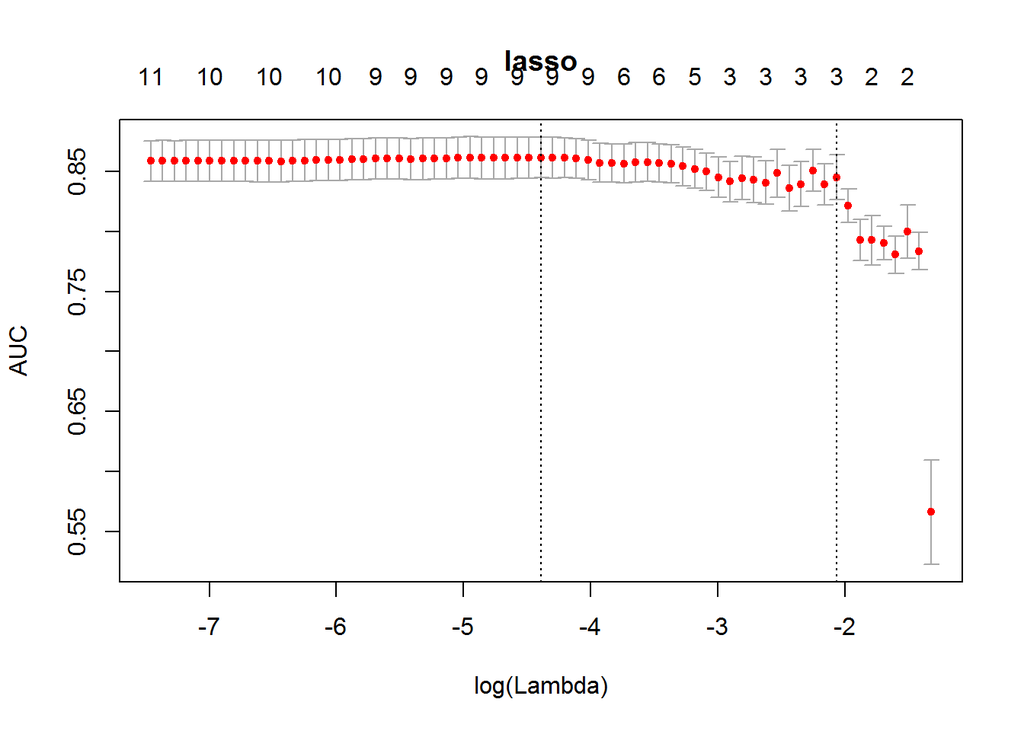

```r
plot(mod.lasso, main="lasso")
```

```r
# Accuracy, Sensitivity, Specificity, and Kappa of the new model using the Full dataset
pred = predict(mod.lasso, s=bestlam.lasso, newx=x, type='response')
optimal.cutoff = apply(cv.OptimalCutoff, 2, mean)[3]
pred.binary = ifelse(pred>=optimal.cutoff, 1, 0)
conf.table = confusionMatrix(table(pred=pred.binary, actual=y))
```

#### Calculate the accuracy, sensitivity, specificity, and Kappa of Model 3:

```r
result = cbind(accuracy = as.numeric(conf.table$overall[1]),
               sensitivity = as.numeric(conf.table$byClass[2]),
               specificity = as.numeric(conf.table$byClass[1]),
               kappa = as.numeric(conf.table$overall[2]))

result = data.frame(result)
rownames(result) = c("Model_3")
result
```

```
##          accuracy sensitivity specificity    kappa
## Model_3 0.7979798   0.7163743    0.848816 0.569586
```

#### Grep the variables which have non-zero coefficients in the Lasso (Model 3):

```r
c = coef(mod.lasso, s=bestlam.lasso, exact=TRUE)
inds = which(c!=0)
(variables = row.names(c)[inds])
```

```
##  [1] "(Intercept)"    "Age"            "logFare"        "EmbarkedS"
##  [5] "Pclass2"        "Pclass3"        "Sex1"           "TitleMr"
##  [9] "TitleMrs"       "TitleOtherMale"
```

```r
result.coef = data.frame(cbind(var=variables, coef=c@x))
result.coef = cbind(result.coef, exp(c@x)-1)
colnames(result.coef) = c("var","coef","exp(coef)-1")
result.coef
```

```
##               var                 coef  exp(coef)-1
## 1     (Intercept)     1.45714696394223  3.293691979
## 2             Age -0.00840692526709336 -0.008371686
## 3         logFare   0.0487090069959644  0.049914788
## 4       EmbarkedS   -0.412420613528479 -0.337954248
## 5         Pclass2   -0.408147392967604 -0.335119127
## 6         Pclass3    -1.62628028286698 -0.803340266
## 7            Sex1    0.753992963415918  1.125470019
## 8         TitleMr    -1.70205983421725 -0.817692386
## 9        TitleMrs    0.200886534864117  0.222486054
## 10 TitleOtherMale    -1.33229055833399 -0.736127846
```

#### Adding Gender*Pclass terms to Model 3:

#### Model 3a: Survived ~ Age + logFare + Embarked + Pclass + Sex + Title + Male_Pclass1 + Male_Pclass2 + Male_Pclass3 + Female_Pclass1 + Female_Pclass2 + Female_Pclass3

```r
dataNew = data
dataNew$Male_Pclass1 = as.factor(ifelse((data$Sex==0 & data$Pclass==1),1,0))
dataNew$Male_Pclass2 = as.factor(ifelse((data$Sex==0 & data$Pclass==2),1,0))
dataNew$Male_Pclass3 = as.factor(ifelse((data$Sex==0 & data$Pclass==3),1,0))
dataNew$Female_Pclass1 = as.factor(ifelse((data$Sex==1 & data$Pclass==1),1,0))
dataNew$Female_Pclass2 = as.factor(ifelse((data$Sex==1 & data$Pclass==2),1,0))
dataNew$Female_Pclass3 = as.factor(ifelse((data$Sex==1 & data$Pclass==3),1,0))

mod3a.xvariables = c("Age","logFare","Embarked","Pclass","Sex","Title","Male_Pclass1",
                     "Male_Pclass2","Male_Pclass3","Female_Pclass1","Female_Pclass2",
                     "Female_Pclass3")
yvariable = c("Survived")

dataset = dataNew[,c(yvariable,mod3a.xvariables)]

# set up of K-fold CV for validation
K = 10
block = sample(1:K, nrow(dataset), replace=TRUE)

# initiate tables for the outputs
cv.result <- matrix(0, K, 3)

for (i in 1:K) {
    train.data = dataset[block!=i,]
    test.data = dataset[block==i,]

    #=========================================================
    # Model 3a: Age+logFare+Embarked+Pclass+Sex+Title+Male_Pclass1+Male_Pclass2+Male_Pclass3
    #           +Female_Pclass1+Female_Pclass2+Female_Pclass3

    train = train.data[,c(yvariable,mod3a.xvariables)]
    test = test.data[,c(yvariable,mod3a.xvariables)]

    x.train = model.matrix(Survived~., train)[,-1]
    y.train = train$Survived

    x.test = model.matrix(Survived~., test)[,-1]
    y.test = test$Survived

    temp = f.lasso.modeller(x.train, y.train, x.test, y.test)

    cv.result[i,1] = temp[1]
    cv.result[i,2] = temp[2]
    cv.result[i,3] = temp[3]

    rm(train.data, test.data, x.train, y.train, x.test, y.test, temp)
}

# output
cv.result = data.frame(cv.result)
colnames(cv.result) = c("log-loss", "optimal.cutoff", "test.accuracy")
rownames(cv.result) = 1:K
cv.result
```

```
##     log-loss optimal.cutoff test.accuracy
## 1  0.4282741           0.47     0.8539326
## 2  0.4771691           0.45     0.7647059
## 3  0.3616413           0.30     0.8000000
## 4  0.4006836           0.43     0.8446602
## 5  0.4276970           0.45     0.7407407
## 6  0.4140357           0.52     0.8045977
## 7  0.4722107           0.45     0.7802198
## 8  0.3961831           0.51     0.8472222
## 9  0.4821008           0.32     0.7666667
## 10 0.4409068           0.42     0.7864078
```

```r
apply(cv.result, 2, mean)
```

```
##       log-loss optimal.cutoff  test.accuracy
##      0.4300902      0.4320000      0.7989154
```

```r
# Build Model 3a using the Full data
x = model.matrix(Survived~., dataset)[,-1]
y = dataset$Survived

mod.lasso = cv.glmnet(x=x, y=y, alpha=1, family='binomial', type.measure='auc', nfolds=10)
(bestlam.lasso = mod.lasso$lambda.min)
```

```
## [1] 0.003370245
```

```r
# Predict using Model 3a
pred = predict(mod.lasso, s=bestlam.lasso, newx=x, type='response')

# Calculate the log-loss of Model 3a
f.logloss(as.numeric(as.character(y)), pred)
```

```
## [1] 0.4164139
```

```r
# Calcuate the accuracy of Model 3a
optimal.cutoff = apply(cv.result, 2, mean)[2]
pred.binary = ifelse(pred>=optimal.cutoff, 1, 0)
conf.table = confusionMatrix(table(pred=pred.binary, actual=y))

result.3a = cbind(accuracy = as.numeric(conf.table$overall[1]),
                  sensitivity = as.numeric(conf.table$byClass[2]),
                  specificity = as.numeric(conf.table$byClass[1]),
                  kappa = as.numeric(conf.table$overall[2]))
result.3a = data.frame(result.3a)
rownames(result.3a) = c("Model_3a")
result.3a = rbind(result, result.3a)
result.3a
```

```
##           accuracy sensitivity specificity     kappa
## Model_3  0.7979798   0.7163743   0.8488160 0.5695860
## Model_3a 0.7991021   0.7426901   0.8342441 0.5759816
```

Adding Gender*Pclass terms to the Model slightly improved the predicting performance in accuracy, sensitivity, and Kappa.

#### Model 3: Survived ~ Age + logFare + Embarked + Pclass + Sex + Title

#### Model 3a: Survived ~ Age + logFare + Embarked + Pclass + Sex + Title + Male_Pclass1 + Male_Pclass2 + Male_Pclass3 + Female_Pclass1 + Female_Pclass2 + Female_Pclass3